# Tarea 1 - Semestre Otoño 2021

Felipe Jorquera D., Constanza Peña S., Matías Salinas M.

05 de mayo de 2021

**Universidad de Chile**

**Ingeniería Industrial**

**IN5602**: Marketing II

**Prof**: Marcel Goic

**Auxs**: R. Cerda, JP. Coddou, G.Mora, F. Moraga, A .Muñoz

## Enunciado

El canal moderno de supermercados ha crecido sostenidamente en todo el mundo y especialmente en los países en desarrollo. En esta tarea exploraremos el comportamiento de compras en una cadena de supermercados en Asia. Para estos efectos, “Supermerca2” ha provisto con información de ventas para tres de sus sucursales (A), (B) y (C) las cuales tienen sedes en las ciudades de Yangon, Mandalay y Naypyidaw respectivamente, en el lejano país de Birmania. “Supermerca2” vende productos de todo tipo, desde accesorios de moda hasta artículos de hogar y estilo de vida. Adicionalmente, la cadena posee un club de lealtad en que los clientes frecuentes pueden registrar sus compras al momento de la compra y así acceder a beneficios posteriormente.

Entre otras preguntas, “Supermerca2” está interesado en entender la satisfacción de sus clientes y así poder decidir sobre qué clientes enfocar los esfuerzos de ventas. En particular, en esta tarea nos concentraremos en entender qué factores afectan el Rating de un cliente, que corresponde a un puntaje en una escala de 10 puntos que indica el grado de satisfacción en la experiencia de compra. El estudio de la satisfacción de los clientes es relevante ya que por un lado nos permite identificar si ciertas salas del supermercado podrían estar entregando un servicio insatisfactorio y por otro nos entrega una señal temprana para saber la probabilidad de que un cliente haga una compra a futuro. En este sentido, la evaluación de la calidad de servicio podría ser informativa respecto al comportamiento de compra futuro.

Para el análisis dispone de una base de datos con una muestra de 1000 compras. El conjunto de datos es uno de los históricos de ventas de la empresa en donde se han registrado IDs de diferentes facturas en sus 3 sucursales durante las horas del día en que atienden. Además, se tienen registros del género del cliente, el precio y la cantidad del producto comprado, la forma de pago, entre otras.

La base de datos está disponible en https://www.kaggle.com/aungpyaeap/supermarket-sales, donde además puede acceder a un diccionario de datos con una descripción de cada una de las variables disponibles en la base de datos.

#### **Preguntas**

1. (0 puntos) Explore los datos para entender la satisfacción de los clientes y qué variables podrían ayudar a predecir cuando un cliente está más satisfecho.
2. (2.0 puntos) Usando los aprendizajes derivados de la exploración de datos, use un enfoque de regresión lineal para examinar cuantitativamente qué factores determinan la satisfacción al momento de realizar una compra.
- 1. Proponga al menos dos especificaciones alternativas para el objetivo propuesto. Justifique muy brevemente por que las variables que está incluyendo en el modelo tienen sentido desde el punto de vista del negocio. Justifique además el nivel de agregación escogido y los índices considerados en el modelo.
- 2. Sobre los dos modelos planteados en la parte anterior, aplique un método de selección automática de variables y compare respecto a los resultados anteriores.
3. (1.0 puntos) Use al menos dos de los modelos de aprendizaje de máquinas que vimos en clases (MARS, kNN, regression tree, random forest) para generar un pronóstico de Rating de un cliente al realizar una compra y compare la capacidad de estos modelos con respecto a los de regresión lineal.
4. (0.5 puntos) Compare las fortalezas y debilidades de los modelos anteriores, evalúe de acuerdo a algunas de las métricas que vimos en clases y discuta qué modelo recomendaría usar.
5. (2.0 puntos) En esta parte, se compararán los grados de satisfacción entre las distintas salas de la cadena de supermercados. Para lo siguiente usted deberá clasificar cada evaluación de la calidad de servicios de acuerdo a si el cliente está o no satisfecho. Para eso puede considerar que un cliente está satisfecho si tiene un Rating mayor o igual a los 7 puntos. Con esto:
- 1. Estimar un modelo de decisión homogéneo para cada sucursal y compare sus resultados entre sucursales. Discuta brevemente sus resultados.
- 2. Estimar un modelo de decisión heterogéneo para cada sucursal y compare sus resultados entre sucursales. Discuta brevemente sus resultados.
- *Observación: Recuerde que la variable utilizada es entera.*
6. (0.5 puntos) Resuma sus aprendizajes principales en un máximo de 4 tablas o figuras. Redacte de manera concisa sus resultados tal como los reportaría al departamento comercial interesado en aprender del comportamiento de clientes. Agregue cualquier conclusión o idea que le parezca relevante de comunicar.

#### **Reglas del juego**

- Las tareas buscan replicar parcialmente las labores a las que se enfrentarían en el análisis de datos en una organización para el apoyo en la toma de decisiones. Por esto, se han propuesto preguntas relativamente abiertas que requieren que ustedes discutan y decidan cual es el mejor enfoque de solución. Les pedimos que se involucren tempranamente en el desarrollo de la tarea para tener una discusión enriquecedora.
- Todas las dudas, comentarios y errores publicarlos exclusivamente en el foro de u-cursos. De esta forma todos se benefician de las respuestas ofrecidas.
- Consideramos que es muy importante que logren escribir un informe conciso con una redacción acorde de un informe técnico profesional, los análisis y las conclusiones que obtengan de cada pregunta es en específico lo que debe declararse. La presentación y comunicación de resultados es parte integral de la tarea y por tanto será evaluada cuidadosamente.
- La tarea se desarrolla en grupos de máximo 3 integrantes. No hay excepciones. El entregable principal es un único markdown separado en tres tabs (a través de la opción .tabset). En el primer tab incluya todo el desarrollo de la tarea adecuadamente comentado. El segundo tab incluya el resumen de sus resultado de acuerdo a lo pedido en la pregunta 6. Este segundo tab es el que usarán en caso de que les corresponda presentar sus resultados. Considere el tercer tab como de anexos y puede incluir aquí cualquier resultado complementario. Para entregar sus resultados suba vía u-cursos un único archivo comprimido llamado t1-A1-A2-A3.zip, donde A1, A2 y A3 es el primer apellido de los integrantes del grupo. Incluya tanto el archivo .html de salida del markdown como los códigos fuentes que permitan reproducir sus resultados.
- Para la pregunta 6 consideramos que 4 figuras son suficientes para resumir los aprendizajes más relevantes, pero si están convencidos de que agregar una figura adicional es absolutamente necesaria, ¡adelante!
- La fecha de entrega de la tarea es el día miércoles 5 de Mayo a las 09:00 hrs, sin excepciones y no habrá plazo extra para la entrega. Si por algún motivo de fuerza mayor se ve imposibilitado de entregar la tarea en el plazo estipulado, deberá escribir directamente al profesor explicando su situación. El profesor decidirá el curso de acción de acuerdo a los méritos del caso.
- Recuerde que tenemos contempladas dos sesiones de presentaciones de las tareas. La primera sesión, a realizarse el día jueves 29 de Abril, está destinada a que compartan sus avances y podamos identificar de manera conjunta cuáles podrían ser dificultades técnicas que requieran orientación adicional. La segunda sesión, a realizarse el día jueves 6 de Mayo, está destinada para que expongan los resultados más relevantes de su trabajo y resuman sus principales aprendizajes, para que tanto los compañeros como el equipo docente puedan proveer retroalimentación. Todos los grupos deben estar disponibles para presentar en ambas ocasiones, pero si hay grupos voluntarios se les dará preferencia. Las presentaciones tendrán una duración máxima de 10 minutos y no es necesario que preparen material adicional. Esperamos que la salida del markdown sea lo suficientemente explicativa para comunicar sus resultados.
- El equipo docente considera que la copia de tareas atenta en contra de tu aprendizaje y por tanto aplicará todas las medidas que estén a su disposición para desincentivar esta mala práctica.

## Preliminares

Escribe acá todos los comandos que necesitas ejecutar antes de abordar las preguntas de la tarea (carga de librerías, lectura de datos, limpieza de la data, transformación de variables y todo lo que necesites)

#### Preparación Tarea

Importamos las librerías a utilizar:

```r
#Exploración de datos
library(tidyr)
library(dplyr)
library(gridExtra)
library(lubridate)
library(grid)
library(ggplot2)
library(GGally)
library(psych)
library(corrplot)
library(ggpubr)
library(ggrepel)
library(caret)
library(knitr)
library(glmnet)
library(MLmetrics)
library(inspectdf)
library(plyr)
library(reshape2)
set.seed(1234)
```

Se importa la base de datos

```r
ventas <- read.csv("supermarket_sales.csv")
print(paste('Las dimensiones de los datos son:', dim(ventas)[1], 'filas y', dim(ventas)[2], 'columnas.'))
```

```
## [1] "Las dimensiones de los datos son: 1000 filas y 17 columnas."
```

```r
print(paste('El dataframe posee:',sum(is.na(ventas)), 'datos vacíos.'))
```

```
## [1] "El dataframe posee: 0 datos vacíos."
```

```r
str(ventas)
```

```
## 'data.frame':    1000 obs. of  17 variables:
##  $ Invoice.ID             : chr  "750-67-8428" "226-31-3081" "631-41-3108" "123-19-1176" ...
##  $ Branch                 : chr  "A" "C" "A" "A" ...
##  $ City                   : chr  "Yangon" "Naypyitaw" "Yangon" "Yangon" ...
##  $ Customer.type          : chr  "Member" "Normal" "Normal" "Member" ...
##  $ Gender                 : chr  "Female" "Female" "Male" "Male" ...
##  $ Product.line           : chr  "Health and beauty" "Electronic accessories" "Home and lifestyle" "Health and beauty" ...
##  $ Unit.price             : num  74.7 15.3 46.3 58.2 86.3 ...
##  $ Quantity               : int  7 5 7 8 7 7 6 10 2 3 ...
##  $ Tax.5.                 : num  26.14 3.82 16.22 23.29 30.21 ...
##  $ Total                  : num  549 80.2 340.5 489 634.4 ...
##  $ Date                   : chr  "1/5/2019" "3/8/2019" "3/3/2019" "1/27/2019" ...
##  $ Time                   : chr  "13:08" "10:29" "13:23" "20:33" ...
##  $ Payment                : chr  "Ewallet" "Cash" "Credit card" "Ewallet" ...
##  $ cogs                   : num  522.8 76.4 324.3 465.8 604.2 ...
##  $ gross.margin.percentage: num  4.76 4.76 4.76 4.76 4.76 ...
##  $ gross.income           : num  26.14 3.82 16.22 23.29 30.21 ...
##  $ Rating                 : num  9.1 9.6 7.4 8.4 5.3 4.1 5.8 8 7.2 5.9 ...
```

Transformamos las variables a un formato correspondiente al tipo de dato que representan:

```r
#Transformamos la variable "género" a binaria
ventas$Gender[ventas$Gender=="Female"]<-1
ventas$Gender[ventas$Gender=="Male"]<-0
ventas$Gender<-as.factor(ventas$Gender)

#Transformamos "Branch", "City" y "Product line" a factor:
ventas$Branch <- as.factor(ventas$Branch)
ventas$City <- as.factor(ventas$City)
ventas$Product.line <- as.factor(ventas$Product.line)
ventas$Payment <- as.factor(ventas$Payment)

#Transformamos la variable "Customer type" a binaria
ventas$Customer.type[ventas$Customer.type=="Member"]<-1
ventas$Customer.type[ventas$Customer.type=="Normal"]<-0
ventas$Customer.type<-as.factor(ventas$Customer.type)


#Transformamos y creamos nuevas variables temporales (dia, hora, fecha)
ventas$Date <- as.Date(ventas$Date, format='%m/%d/%Y')
ventas$Date_time <- as.POSIXct(paste(ventas$Date, ventas$Time), format="%Y-%m-%d %H:%M")
ventas$Time <- as.POSIXct(ventas$Time, format="%H:%M")
ventas$Weekday <- weekdays(ventas$Date)
ventas$Weekday = factor(ventas$Weekday, levels=c('lunes','martes','miércoles','jueves', 'viernes', 'sábado', 'domingo'))
ventas$Hour_num <- hour(ventas$Time) + minute(ventas$Time)/60
ventas$dia<-format(as.Date(ventas$Date,format="%Y-%m-%d"), format = "%d")

str(ventas)
```

```
## 'data.frame':    1000 obs. of  21 variables:
##  $ Invoice.ID             : chr  "750-67-8428" "226-31-3081" "631-41-3108" "123-19-1176" ...
##  $ Branch                 : Factor w/ 3 levels "A","B","C": 1 3 1 1 1 3 1 3 1 2 ...
##  $ City                   : Factor w/ 3 levels "Mandalay","Naypyitaw",..: 3 2 3 3 3 2 3 2 3 1 ...
##  $ Customer.type          : Factor w/ 2 levels "0","1": 2 1 1 2 1 1 2 1 2 2 ...
##  $ Gender                 : Factor w/ 2 levels "0","1": 2 2 1 1 1 1 2 2 2 2 ...
##  $ Product.line           : Factor w/ 6 levels "Electronic accessories",..: 4 1 5 4 6 1 1 5 4 3 ...
##  $ Unit.price             : num  74.7 15.3 46.3 58.2 86.3 ...
##  $ Quantity               : int  7 5 7 8 7 7 6 10 2 3 ...
##  $ Tax.5.                 : num  26.14 3.82 16.22 23.29 30.21 ...
##  $ Total                  : num  549 80.2 340.5 489 634.4 ...
##  $ Date                   : Date, format: "2019-01-05" "2019-03-08" ...
##  $ Time                   : POSIXct, format: "2021-05-12 13:08:00" "2021-05-12 10:29:00" ...
##  $ Payment                : Factor w/ 3 levels "Cash","Credit card",..: 3 1 2 3 3 3 3 3 2 2 ...
##  $ cogs                   : num  522.8 76.4 324.3 465.8 604.2 ...
##  $ gross.margin.percentage: num  4.76 4.76 4.76 4.76 4.76 ...
##  $ gross.income           : num  26.14 3.82 16.22 23.29 30.21 ...
##  $ Rating                 : num  9.1 9.6 7.4 8.4 5.3 4.1 5.8 8 7.2 5.9 ...
##  $ Date_time              : POSIXct, format: "2019-01-05 13:08:00" "2019-03-08 10:29:00" ...
##  $ Weekday                : Factor w/ 7 levels "lunes","martes",..: 6 5 7 7 5 1 1 7 4 3 ...
##  $ Hour_num               : num  13.1 10.5 13.4 20.6 10.6 ...
##  $ dia                    : chr  "05" "08" "03" "27" ...
```

## Desarrollo

Documenta acá el desarrollo de tu tarea por pregunta.

#### Pregunta 1

(0 puntos) Explore los datos para entender la satisfacción de los clientes y qué variables podrían ayudar a predecir cuando un cliente está más satisfecho.

Se analiza la composición de la base de datos con la función **summary**:

```r
summary(ventas)
```

```
##   Invoice.ID        Branch         City     Customer.type Gender
##  Length:1000        A:340   Mandalay :332   0:499         0:499
##  Class :character   B:332   Naypyitaw:328   1:501         1:501
##  Mode  :character   C:328   Yangon   :340
##
##
##
##
##                  Product.line   Unit.price       Quantity         Tax.5.
##  Electronic accessories:170   Min.   :10.08   Min.   : 1.00   Min.   : 0.5085
##  Fashion accessories   :178   1st Qu.:32.88   1st Qu.: 3.00   1st Qu.: 5.9249
##  Food and beverages    :174   Median :55.23   Median : 5.00   Median :12.0880
##  Health and beauty     :152   Mean   :55.67   Mean   : 5.51   Mean   :15.3794
##  Home and lifestyle    :160   3rd Qu.:77.94   3rd Qu.: 8.00   3rd Qu.:22.4453
##  Sports and travel     :166   Max.   :99.96   Max.   :10.00   Max.   :49.6500
##
##      Total              Date                 Time
##  Min.   :  10.68   Min.   :2019-01-01   Min.   :2021-05-12 10:00:00
##  1st Qu.: 124.42   1st Qu.:2019-01-24   1st Qu.:2021-05-12 12:43:00
##  Median : 253.85   Median :2019-02-13   Median :2021-05-12 15:19:00
##  Mean   : 322.97   Mean   :2019-02-14   Mean   :2021-05-12 15:24:41
##  3rd Qu.: 471.35   3rd Qu.:2019-03-08   3rd Qu.:2021-05-12 18:15:00
##  Max.   :1042.65   Max.   :2019-03-30   Max.   :2021-05-12 20:59:00
##
##         Payment         cogs        gross.margin.percentage  gross.income
##  Cash       :344   Min.   : 10.17   Min.   :4.762           Min.   : 0.5085
##  Credit card:311   1st Qu.:118.50   1st Qu.:4.762           1st Qu.: 5.9249
##  Ewallet    :345   Median :241.76   Median :4.762           Median :12.0880
##                    Mean   :307.59   Mean   :4.762           Mean   :15.3794
##                    3rd Qu.:448.90   3rd Qu.:4.762           3rd Qu.:22.4453
##                    Max.   :993.00   Max.   :4.762           Max.   :49.6500
##
##      Rating         Date_time                        Weekday       Hour_num
##  Min.   : 4.000   Min.   :2019-01-01 10:39:00   lunes    :125   Min.   :10.00
##  1st Qu.: 5.500   1st Qu.:2019-01-24 17:58:45   martes   :158   1st Qu.:12.72
##  Median : 7.000   Median :2019-02-13 17:37:00   miércoles:143   Median :15.32
##  Mean   : 6.973   Mean   :2019-02-14 15:30:27   jueves   :138   Mean   :15.41
##  3rd Qu.: 8.500   3rd Qu.:2019-03-08 15:29:30   viernes  :139   3rd Qu.:18.25
##  Max.   :10.000   Max.   :2019-03-30 20:37:00   sábado   :164   Max.   :20.98
##                                                 domingo  :133
##      dia
##  Length:1000
##  Class :character
##  Mode  :character
##
##
##
##
```

Las variables categoricas tienen una distribución similiar entre sus distintos valores, por lo que no hay un gran desbalance entre clases. Además, dado que la variable *gross.margin.percentage* no posee varianza alguna (su mínimo y máximo son iguales), se conlcuye que no aporta información al problema y debe ser eliminada. Sobre las otras variables númericas, a simple vista los percentiles parecen indicar que no hay outliers de gran magnitud en las variables. Para confirmar este supuesto se realiza un histograma para cada variable numérica:

[figure not shown]

Los histogramas de las variables *cogs, gross.income, Tax 5% y Total* son muy similares entre si, por lo cual puede existir un problema de correlación.

A través de un diagrama de correlaciones se puede visualizar la relación existente entre las variables numéricas:

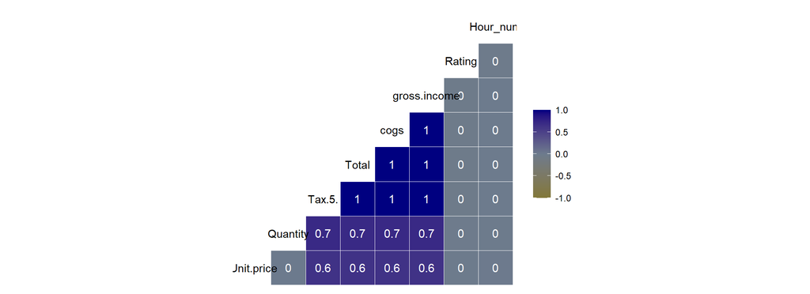

Se observa que *Rating* tiene correlación 0 con todas las demás variables, y varias variables tienen correlación 1, esto debido a que las variables *Tax 5%, cogs y gross income* son un porcentaje de la variable *Total*. Dicha correlación se tendrá en cuenta al correr los modelos de las preguntas siguientes.

Respecto a las variables tipo *character*, se puede obtener una muestra aleatoria para observar de que trata cada una. En particular notando que *Product.line*, *City*, *Payment*, *Gender*, *Branch* y *Customer.type* son formas claras de categorizar clientes.

Viendo las variables tipo no numérica:

[figure not shown]

Con ello se puede observar que la mayoría de estas categorías están repartidas con igual porcentaje dentro de la base de datos, siendo la excepción las fechas, donde existen algunos días de la semana más frecuentes que otros. Otro dato interesante es que las Tiendas tienen una distribución similar a la variable *City*. Para explorar aún más su relación, se genera el siguiente barplot:

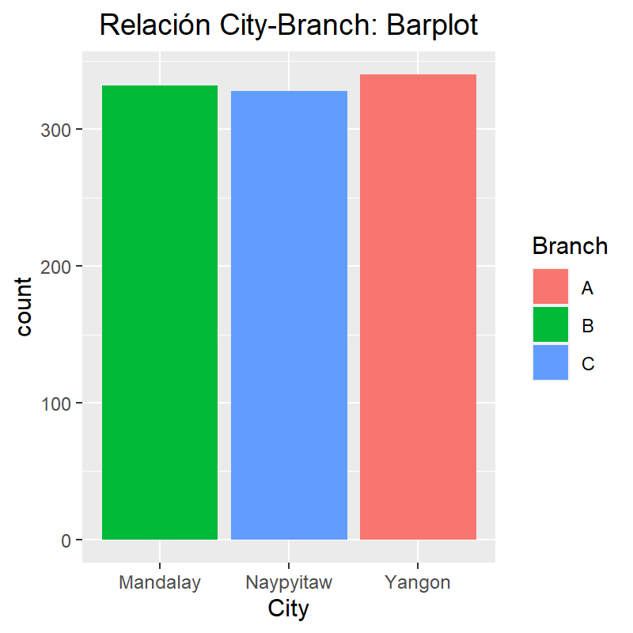

Lo anterior indica que la ciudad de Yangon tiene el supermercado A, la ciudad Mandalay tiene al supermercado B y los centros C están unicamente en Naypyitaw. Dado lo anterior, hablar sobre *Branch* o *City* será equivalente desde ahora en adelante.

Ahora, si se analiza cómo se comportan las variables en función de la satisfacción, se pueden ver los siguientes gráficos respecto a las variables numéricas, donde se observa que la satisfacción se comporta de manera equitativa para todos los valores de la variable númerica y no emerge ninguna relación aparante.

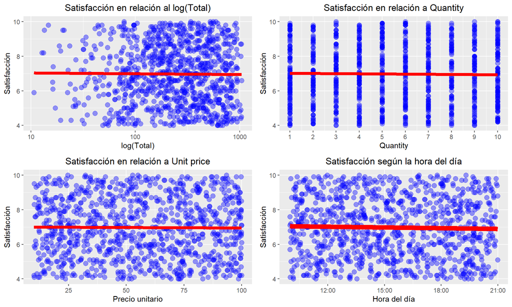

Se analiza el comportamiento de la satisfacción con respecto a otras variables relevantes mediante los siguientes gráficos:

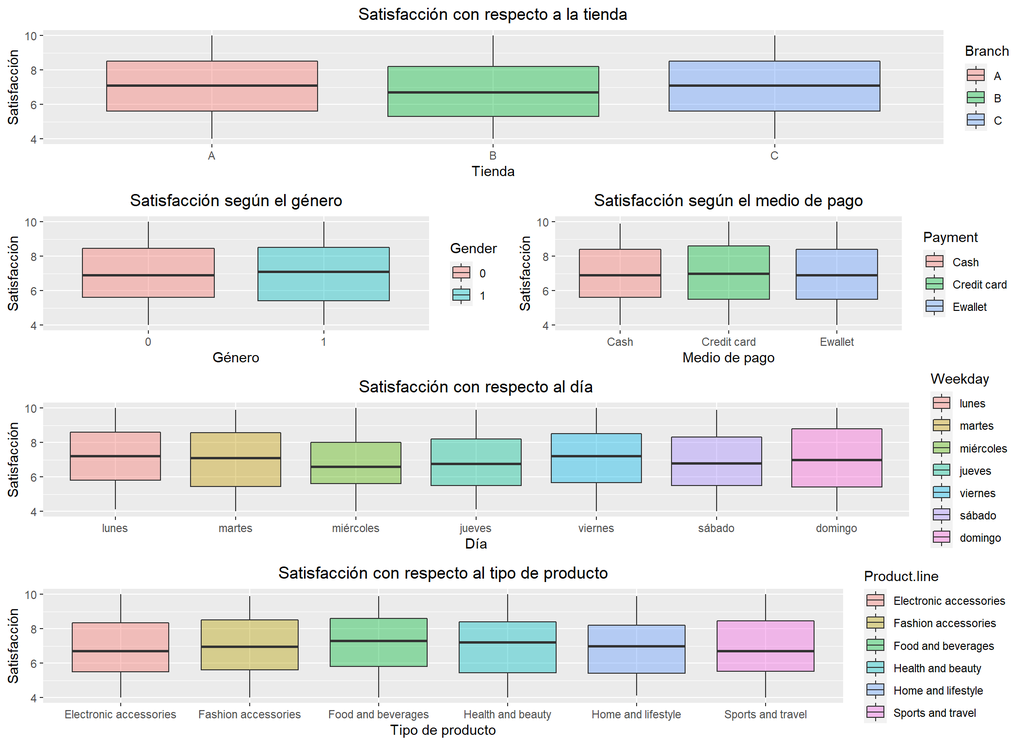

A simple vista no existen relaciones muy marcadas entre las comparaciones. Según los gráficos, la tienda con menor nivel de Rating es la Tienda B, además, los días con menor satisfacción son los Miércoles, Jueves y Sábados. Sobre los productos, *Sports and travel* y *Electronic accessories* poseen el menor nivel de satisfacción. Con respecto al género del cliente, no se muestran diferencias marcadas de satisfacción, tampoco sobre el medio de pago.

Dado que analizar unicamente la interacción de una variable no arroja resultados muy evidentes, se generan boxplot que reunan algunas combinaciones de variables para poder explicar al *Rating*.

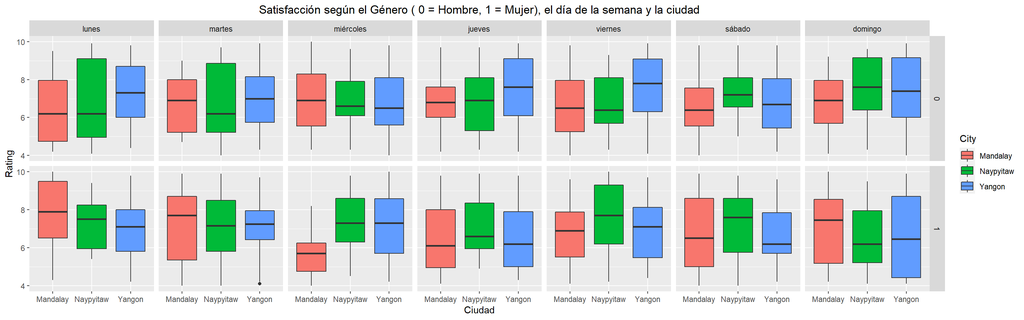

De esta interacción se observan varios resultados interesantes: los miércoles las mujeres de mandalay tienen una baja satisfacción, en comparación con el resto de ciudades y de días.

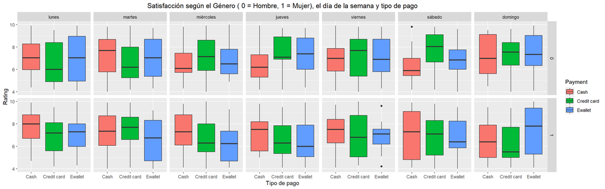

Se puede observar que los miercoles y los jueves varía el tipo de pago seún género, y los días sádados los hombres que pagan con efectivo califican peor.

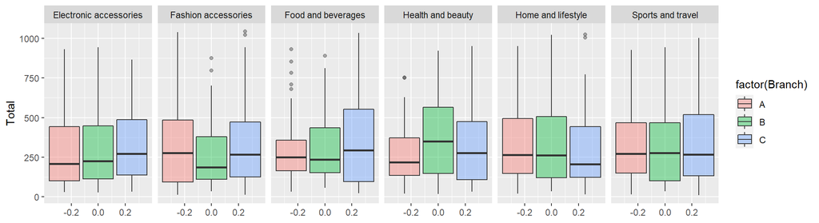

```r
g <- ggplot(ventas, aes(y=Total, fill=factor(Branch))) + geom_boxplot(alpha=0.4)+ facet_grid(.~Product.line)
g
```

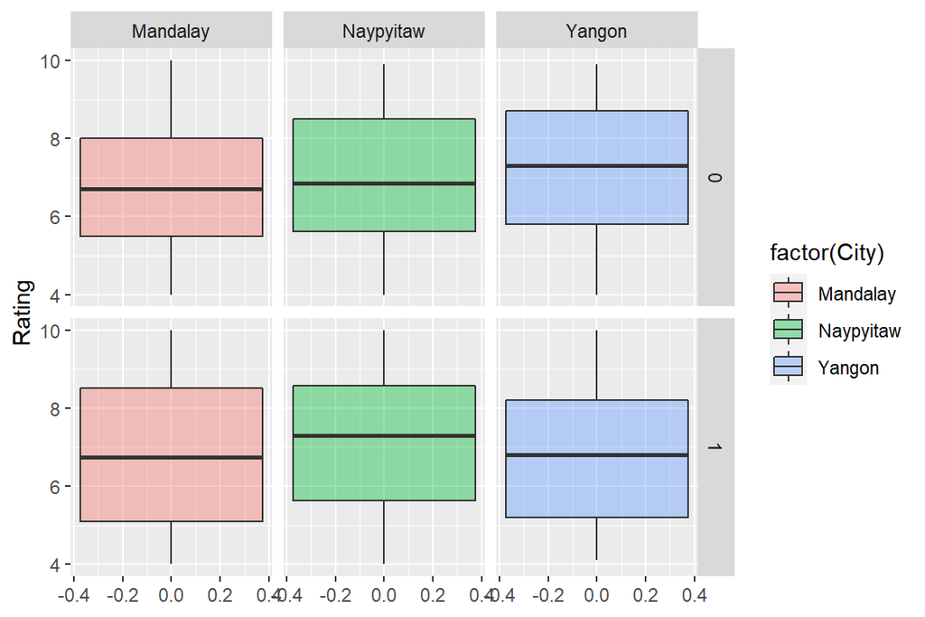

```r
g <- ggplot(ventas, aes(y=Rating, fill=factor(City))) + geom_boxplot(alpha=0.4)+ facet_grid(Gender~City)
g
```

Con esta interacción se puede observar que el rating cambia ligeramente en promedio al realizar la interacción ciudad y género.

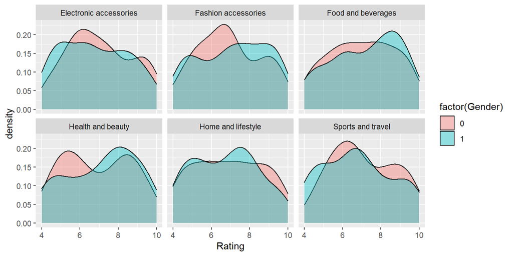

```r
g3 <- ggplot(ventas, aes(x=Rating, fill=factor(Gender))) + geom_density(alpha=0.4)+
  facet_wrap(.~Product.line, ncol = 3)
g3
```

Finalemente, aunque las diferencias de segmentos no son muy notables dado lo equilibrados que son los datos de las ventas, si existen diferencias que salen a la luz de realizar interacciones de variables lo cual vale tener en cuenta para el estudio.

Como se mencionó anteriormente, hay variables que tienen una correlación perfecta o que no tienen varianza alguna. La presencia de estos factores puede afectar de manera significativa el desarrolllo de las preguntas siguientes, por lo que serán eliminadas.

```r
ventas <- subset(ventas, select = -c(gross.margin.percentage, gross.income, Tax.5.,cogs,Date_time,Date))
head(ventas)
```

```
##    Invoice.ID Branch      City Customer.type Gender           Product.line
## 1 750-67-8428      A    Yangon             1      1      Health and beauty
## 2 226-31-3081      C Naypyitaw             0      1 Electronic accessories
## 3 631-41-3108      A    Yangon             0      0     Home and lifestyle
## 4 123-19-1176      A    Yangon             1      0      Health and beauty
## 5 373-73-7910      A    Yangon             0      0      Sports and travel
## 6 699-14-3026      C Naypyitaw             0      0 Electronic accessories
##   Unit.price Quantity    Total                Time     Payment Rating Weekday
## 1      74.69        7 548.9715 2021-05-12 13:08:00     Ewallet    9.1  sábado
## 2      15.28        5  80.2200 2021-05-12 10:29:00        Cash    9.6 viernes
## 3      46.33        7 340.5255 2021-05-12 13:23:00 Credit card    7.4 domingo
## 4      58.22        8 489.0480 2021-05-12 20:33:00     Ewallet    8.4 domingo
## 5      86.31        7 634.3785 2021-05-12 10:37:00     Ewallet    5.3 viernes
## 6      85.39        7 627.6165 2021-05-12 18:30:00     Ewallet    4.1   lunes
##   Hour_num dia
## 1 13.13333  05
## 2 10.48333  08
## 3 13.38333  03
## 4 20.55000  27
## 5 10.61667  08
## 6 18.50000  25
```

#### Pregunta 2

(2.0 puntos) Usando los aprendizajes derivados de la exploración de datos, use un enfoque de regresión lineal para examinar cuantitativamente qué factores determinan la satisfacción al momento de realizar una compra.

```r
# Construimos un vector que esta formado por números de filas aleatoriamente
index <- sample(1:nrow(ventas), size= nrow(ventas)*0.7)

# Base de entrenamiento: del total de datos, tomamos las filas aletorizadas que tienen datos en index
train <- ventas[index, ]

# Anteponiendo el "-" escogemos las filas en de la base que no están en index
xtrain <- subset(train, select = -c(Rating))
ytrain <- train$Rating

# Se quitan variables correlacionadas
test  <- ventas[-index, ]
xtest <- subset(test, select = -c(Rating))
ytest <- test$Rating
```

Para comenzar esta sección, se crea un *train set* y un *test set*, con una proporción de 70%:30%. En el set de variables *xtrain* se eliminaron algunas variables que estaban altamente correlacionadas con otras, y la ganancia por producto ya que es constante, y no servirá como variable predictora. También se elimina la variable a predecir, *Rating*.

**a)** Proponga al menos dos especificaciones alternativas para el objetivo propuesto. Justifique muy brevemente por que las variables que está incluyendo en el modelo tienen sentido desde el punto de vista del negocio. Justifique además el nivel de agregación escogido y los índices considerados en el modelo.

**R.:** El rating según los datos provistos por la cadena de supermercados, puede depender de 4 tipos de dimensiones: caracterización de la compra (dada por las variables *Gender*, *Payment*, *Total*, entre otras), zona geográfica de la compra (dada por las variables *Branch* y *City*), tipo de producto (dado por la variable *Product.line*, entre otras) y caracterización temporal (dada por las variables *Weekday*, *Time*, entre otras).

En una primera regresión se propone un modelo de regresión lineal de interacción triple entre las variables *City*, *Gender* y *Weekday*. Es esperable pensar que el rating asignado por los clientes varíe en cada ciudad, por distintas razones incluso más allá de motivos relacionados a la tienda misma. Y de igual forma tiene sentido que los ratings sean distintos dependiendo del día de la semana en que se tome la muestra, esto último respaldado por el EDA realizado. Finalmente, en el EDA se encontraron diferencias con respecto al género, lo cual se busca estudiar más a detalle.

En esta regresión se están estudiando efectos en 3 de las 4 dimensiones anteriormente señaladas: la caracterización de la compra, la zona geográfica y la caracterización temporal. El nivel de agregación fue escogido gracias a lo observado en gráficas al realizar el EDA, ya que en particular se observaron cambios en el rating según el día de la semana, al contrastarlo según género y ciudad.

```r
lm1 <- lm(Rating ~ City*Gender*Weekday, data=ventas) #regresión lineal 1 con datos
summary(lm1)
```

```
##
## Call:
## lm(formula = Rating ~ City * Gender * Weekday, data = ventas)
##
## Residuals:
##     Min      1Q  Median      3Q     Max
## -3.5500 -1.3787 -0.0546  1.4353  3.3042
##
## Coefficients:
##                                        Estimate Std. Error t value Pr(>|t|)
## (Intercept)                             6.51333    0.44260  14.716  < 2e-16 ***
## CityNaypyitaw                           0.36493    0.56891   0.641 0.521382
## CityYangon                              0.73930    0.59207   1.249 0.212096
## Gender1                                 1.33667    0.56421   2.369 0.018029 *
## Weekdaymartes                           0.32758    0.57399   0.571 0.568336
## Weekdaymiércoles                        0.42215    0.53915   0.783 0.433827
## Weekdayjueves                           0.43067    0.55985   0.769 0.441935
## Weekdayviernes                          0.09312    0.53915   0.173 0.862914
## Weekdaysábado                           0.12000    0.55202   0.217 0.827957
## Weekdaydomingo                          0.27088    0.59207   0.458 0.647412
## CityNaypyitaw:Gender1                  -0.93493    0.80124  -1.167 0.243562
## CityYangon:Gender1                     -1.59275    0.75783  -2.102 0.035840 *
## CityNaypyitaw:Weekdaymartes            -0.34045    0.75514  -0.451 0.652203
## CityYangon:Weekdaymartes               -0.51499    0.78223  -0.658 0.510462
## CityNaypyitaw:Weekdaymiércoles         -0.53374    0.74724  -0.714 0.475224
## CityYangon:Weekdaymiércoles            -0.89700    0.74443  -1.205 0.228517
## CityNaypyitaw:Weekdayjueves            -0.61293    0.74748  -0.820 0.412427
## CityYangon:Weekdayjueves               -0.35130    0.76526  -0.459 0.646299
## CityNaypyitaw:Weekdayviernes           -0.12523    0.80279  -0.156 0.876076
## CityYangon:Weekdayviernes               0.27425    0.73708   0.372 0.709919
## CityNaypyitaw:Weekdaysábado             0.25826    0.74850   0.345 0.730140
## CityYangon:Weekdaysábado               -0.59115    0.75380  -0.784 0.433101
## CityNaypyitaw:Weekdaydomingo            0.41402    0.79559   0.520 0.602911
## CityYangon:Weekdaydomingo              -0.03065    0.78112  -0.039 0.968707
## Gender1:Weekdaymartes                  -1.06145    0.73938  -1.436 0.151447
## Gender1:Weekdaymiércoles               -2.60899    0.75351  -3.462 0.000559 ***
## Gender1:Weekdayjueves                  -1.78067    0.76846  -2.317 0.020703 *
## Gender1:Weekdayviernes                 -1.11312    0.74836  -1.487 0.137236
## Gender1:Weekdaysábado                  -1.14879    0.71848  -1.599 0.110168
## Gender1:Weekdaydomingo                 -1.10838    0.81033  -1.368 0.171695
## CityNaypyitaw:Gender1:Weekdaymartes     0.82647    1.04322   0.792 0.428425
## CityYangon:Gender1:Weekdaymartes        1.30588    1.01753   1.283 0.199669
## CityNaypyitaw:Gender1:Weekdaymiércoles  2.71990    1.06428   2.556 0.010753 *
## CityYangon:Gender1:Weekdaymiércoles     3.23729    1.05652   3.064 0.002244 **
## CityNaypyitaw:Gender1:Weekdayjueves     1.90901    1.07679   1.773 0.076567 .
## CityYangon:Gender1:Weekdayjueves        1.21903    1.05070   1.160 0.246253
## CityNaypyitaw:Gender1:Weekdayviernes    1.36923    1.10782   1.236 0.216776
## CityYangon:Gender1:Weekdayviernes       0.59920    1.03000   0.582 0.560874
## CityNaypyitaw:Gender1:Weekdaysábado     0.70020    1.03073   0.679 0.497095
## CityYangon:Gender1:Weekdaysábado        1.32773    1.00438   1.322 0.186503
## CityNaypyitaw:Gender1:Weekdaydomingo   -0.20467    1.11525  -0.184 0.854431
## CityYangon:Gender1:Weekdaydomingo       0.46743    1.06771   0.438 0.661637
## ---
## Signif. codes:  0 '***' 0.001 '**' 0.01 '*' 0.05 '.' 0.1 ' ' 1
##
## Residual standard error: 1.714 on 958 degrees of freedom
## Multiple R-squared:  0.04593,    Adjusted R-squared:  0.005101
## F-statistic: 1.125 on 41 and 958 DF,  p-value: 0.2744
```

En esta regresión se observa que, de manera significativa, el género femenino puntúa un rating de satisfacción mayor, específicamente aumentando el rating en 1,337. Este efecto se intensifica los días miércoles en las ciudades de Yangon y Naypyitaw, en donde el rating femenino es 3,237 y 2,720 puntos más alto, respectivamente.

Sin embargo, este es un efecto muy particular, al que se debe tener en cuenta. La regresión indica también que, en general, los miércoles y jueves el género femenino puntúa 2,609 y 1,781 puntos más bajo en el rating, respectivamente. Es más, en la ciudad de Yangon las mujeres puntúan en promedio un ranking de 1,593 puntos más bajo que el promedio, por lo que se debe estudiar más a fondo lo que sucede en las tiendas de Yangon y Naypyitaw los miércoles para contraarrestar la estadística.

En una segunda regresión se propone un modelo de regresión lineal con interacción triple entre las variables *Gender*, *Payment* y *Weekday*. Tal como se señaló para la regresión anterior, las emociones de las personas varían según el día de la semana, y esto puede afectar al rating. De igual manera el género afecta al rating, como se observó en la regresión anterior. Finalmente, se agrega el tipo de pago debido a que se desea analizar si este tiene un efecto en el rating, el cual puede deberse a deficiencias en las tecnologías dispuestas para el pago y que puedan afectar la satisfacción del cliente.

En esta regresión se están estudiando efectos en 2 de las 4 dimensiones anteriormente señaladas: la caracterización de la compra y una caracterización temporal. El nivel de agregación escogido se debe a un gráfico realizado con anterioridad en el EDA, en donde se observan cambios en el rating al comparar por estas 3 variables simultáneamente.

```r
lm2 <- lm(Rating ~ Gender*Weekday*Payment, data=ventas)
summary(lm2)
```

```
##
## Call:
## lm(formula = Rating ~ Gender * Weekday * Payment, data = ventas)
##
## Residuals:
##     Min      1Q  Median      3Q     Max
## -3.5500 -1.3340 -0.0323  1.4000  3.4741
##
## Coefficients:
##                                             Estimate Std. Error t value
## (Intercept)                                  7.04167    0.34967  20.138
## Gender1                                      0.78442    0.49985   1.569
## Weekdaymartes                                0.08833    0.51864   0.170
## Weekdaymiércoles                            -0.49936    0.48490  -1.030
## Weekdayjueves                               -0.57270    0.47271  -1.212
## Weekdayviernes                              -0.18258    0.50562  -0.361
## Weekdaysábado                               -0.71574    0.48057  -1.489
## Weekdaydomingo                               0.09722    0.53413   0.182
## PaymentCredit card                          -0.50049    0.54303  -0.922
## PaymentEwallet                               0.05208    0.55288   0.094
## Gender1:Weekdaymartes                       -0.69442    0.70313  -0.988
## Gender1:Weekdaymiércoles                    -0.07435    0.70884  -0.105
## Gender1:Weekdayjueves                        0.07786    0.73106   0.107
## Gender1:Weekdayviernes                      -0.36274    0.70434  -0.515
## Gender1:Weekdaysábado                       -0.02247    0.66892  -0.034
## Gender1:Weekdaydomingo                      -1.41296    0.71698  -1.971
## Gender1:PaymentCredit card                  -0.29226    0.74980  -0.390
## Gender1:PaymentEwallet                      -0.67817    0.74534  -0.910
## Weekdaymartes:PaymentCredit card            -0.05994    0.75445  -0.079
## Weekdaymiércoles:PaymentCredit card          1.08895    0.72153   1.509
## Weekdayjueves:PaymentCredit card             1.41976    0.75411   1.883
## Weekdayviernes:PaymentCredit card            0.79854    0.75366   1.060
## Weekdaysábado:PaymentCredit card             1.92456    0.74181   2.594
## Weekdaydomingo:PaymentCredit card            0.70743    0.76169   0.929
## Weekdaymartes:PaymentEwallet                -0.11780    0.74646  -0.158
## Weekdaymiércoles:PaymentEwallet              0.24265    0.72610   0.334
## Weekdayjueves:PaymentEwallet                 0.75826    0.71277   1.064
## Weekdayviernes:PaymentEwallet                0.22431    0.73056   0.307
## Weekdaysábado:PaymentEwallet                 0.39866    0.71566   0.557
## Weekdaydomingo:PaymentEwallet                0.20903    0.76874   0.272
```

[output cut: 46 more lines]

```
## Gender1:Weekdayviernes:PaymentCredit card    0.78604
## Gender1:Weekdaysábado:PaymentCredit card     0.19059
## Gender1:Weekdaydomingo:PaymentCredit card    0.80586
## Gender1:Weekdaymartes:PaymentEwallet         0.91317
## Gender1:Weekdaymiércoles:PaymentEwallet      0.54531
## Gender1:Weekdayjueves:PaymentEwallet         0.38336
## Gender1:Weekdayviernes:PaymentEwallet        0.99054
## Gender1:Weekdaysábado:PaymentEwallet         0.92075
## Gender1:Weekdaydomingo:PaymentEwallet        0.19162
## ---
## Signif. codes:  0 '***' 0.001 '**' 0.01 '*' 0.05 '.' 0.1 ' ' 1
##
## Residual standard error: 1.713 on 958 degrees of freedom
## Multiple R-squared:  0.04723,    Adjusted R-squared:  0.006456
## F-statistic: 1.158 on 41 and 958 DF,  p-value: 0.2313
```

Esta regresión entrega pocos datos interesantes con alta significancia. Según esta regresión lineal, los domingos el género femenino puntúa en promedio un rating 1,413 más bajo. También se puede decir que los clientes que pagan con tarjeta de crédito los sábados tienen un nivel de satisfacción mayor, lo cual se ve reflejado en un aumento de 1,925 puntos en el rating.

Como conclusión de las regresiones lineales, se debe estudiar la razón de que en algunos días de la semana las clientas punteen más bajo en el rating, en particular en la tienda de Yangon. También se debe analizar con más detalle la receta de las tiendas de Yangon y Naypyitaw para mejorar el rating señalado por las clientas los días miércoles.

**b)** Sobre los dos modelos planteados en la parte anterior, aplique un método de selección automática de variables y compare respecto a los resultados anteriores.

**R.:** El método de selección adecuado para este caso es **Lasso**. Para esto, primero se crea una matriz con las interacciones respectivas en cada regresión para poder entregarle esto a la función *glmnet* y que el algoritmo funcione, con un lambda igual a 0,05.

```r
interaccion_lm1 <- model.matrix(~City*Gender*Weekday, data=ventas)

Lasso1 <- glmnet(interaccion_lm1, ventas$Rating, alpha=1, lambda=0.05) #modelo Lasso de autoselección
coef(Lasso1) #impresión de coeficientes
```

```
## 43 x 1 sparse Matrix of class "dgCMatrix"
##                                                  s0
## (Intercept)                             6.962068794
## (Intercept)                             .
## CityNaypyitaw                           .
## CityYangon                              .
## Gender1                                 .
## Weekdaymartes                           .
## Weekdaymiércoles                       -0.052841775
## Weekdayjueves                           .
## Weekdayviernes                          .
## Weekdaysábado                           .
## Weekdaydomingo                          .
## CityNaypyitaw:Gender1                   0.092422592
## CityYangon:Gender1                      .
## CityNaypyitaw:Weekdaymartes             .
## CityYangon:Weekdaymartes                .
## CityNaypyitaw:Weekdaymiércoles          .
## CityYangon:Weekdaymiércoles             .
## CityNaypyitaw:Weekdayjueves             .
## CityYangon:Weekdayjueves                .
## CityNaypyitaw:Weekdayviernes            .
## CityYangon:Weekdayviernes               0.131968240
## CityNaypyitaw:Weekdaysábado             0.005217993
## CityYangon:Weekdaysábado                .
## CityNaypyitaw:Weekdaydomingo            .
## CityYangon:Weekdaydomingo               .
## Gender1:Weekdaymartes                   .
## Gender1:Weekdaymiércoles                .
## Gender1:Weekdayjueves                   .
## Gender1:Weekdayviernes                  .
## Gender1:Weekdaysábado                   .
## Gender1:Weekdaydomingo                 -0.089327984
## CityNaypyitaw:Gender1:Weekdaymartes     .
## CityYangon:Gender1:Weekdaymartes        .
## CityNaypyitaw:Gender1:Weekdaymiércoles  .
## CityYangon:Gender1:Weekdaymiércoles     .
## CityNaypyitaw:Gender1:Weekdayjueves     .
## CityYangon:Gender1:Weekdayjueves       -0.106415028
## CityNaypyitaw:Gender1:Weekdayviernes    0.137244454
## CityYangon:Gender1:Weekdayviernes       .
## CityNaypyitaw:Gender1:Weekdaysábado     .
## CityYangon:Gender1:Weekdaysábado        .
## CityNaypyitaw:Gender1:Weekdaydomingo   -0.013157269
## CityYangon:Gender1:Weekdaydomingo       .
```

Las constantes entregadas por el modelo Lasso varían bastante con respecto a las entregadas por la regresión lineal. Por ejemplo, el día miércoles por sí solo no era significativo en la regresión lineal mientras que según el modelo Lasso (con lambda igual a 0,05) sí lo es. También la interacción entre el género femenino y la ciudad Yangon, que según la regresión lineal es significativa pero según el modelo Lasso no lo es.

```r
interaccion_lm2 <- model.matrix(~Gender*Weekday*Payment, data=ventas)

Lasso2 <- glmnet(interaccion_lm2, ventas$Rating, alpha=1, lambda=0.05)
coef(Lasso2)
```

```
## 43 x 1 sparse Matrix of class "dgCMatrix"
##                                                       s0
## (Intercept)                                  6.982209039
## (Intercept)                                  .
## Gender1                                      .
## Weekdaymartes                                .
## Weekdaymiércoles                             .
## Weekdayjueves                                .
## Weekdayviernes                               .
## Weekdaysábado                                .
## Weekdaydomingo                               .
## PaymentCredit card                           .
## PaymentEwallet                               .
## Gender1:Weekdaymartes                        .
## Gender1:Weekdaymiércoles                     .
## Gender1:Weekdayjueves                        .
## Gender1:Weekdayviernes                       .
## Gender1:Weekdaysábado                        .
## Gender1:Weekdaydomingo                      -0.051322509
## Gender1:PaymentCredit card                   .
## Gender1:PaymentEwallet                      -0.013382289
## Weekdaymartes:PaymentCredit card             .
## Weekdaymiércoles:PaymentCredit card          .
## Weekdayjueves:PaymentCredit card             .
## Weekdayviernes:PaymentCredit card            .
## Weekdaysábado:PaymentCredit card             0.054523772
## Weekdaydomingo:PaymentCredit card            .
## Weekdaymartes:PaymentEwallet                 .
## Weekdaymiércoles:PaymentEwallet             -0.013557875
## Weekdayjueves:PaymentEwallet                 .
## Weekdayviernes:PaymentEwallet                .
## Weekdaysábado:PaymentEwallet                -0.002218837
## Weekdaydomingo:PaymentEwallet                0.242182038
## Gender1:Weekdaymartes:PaymentCredit card     0.107865444
## Gender1:Weekdaymiércoles:PaymentCredit card  .
## Gender1:Weekdayjueves:PaymentCredit card    -0.033376471
## Gender1:Weekdayviernes:PaymentCredit card    .
## Gender1:Weekdaysábado:PaymentCredit card     .
## Gender1:Weekdaydomingo:PaymentCredit card   -0.385887135
## Gender1:Weekdaymartes:PaymentEwallet        -0.088457167
## Gender1:Weekdaymiércoles:PaymentEwallet     -0.360246525
## Gender1:Weekdayjueves:PaymentEwallet        -0.102804027
## Gender1:Weekdayviernes:PaymentEwallet        .
## Gender1:Weekdaysábado:PaymentEwallet         .
## Gender1:Weekdaydomingo:PaymentEwallet        .
```

Este modelo Lasso entrega muchas constantes significativas, en comparación al modelo de regresión lineal que solo entregaba 2 constantes con alta significancia. Para este caso, el modelo Lasso si considera significativas las mismas 2 constantes de la regresión lineal, aunque los valores del modelo Lasso son más cercanos a cero. Sin embargo, el modelo Lasso entrega 10 otras constantes significativas, de las cuales solo 2 constantes son positivas. La razón de esto puede ser el valor de lambda, el cual tendría que ser mayor para funcionar de mejor manera.

#### Pregunta 3

(1.0 puntos)Use al menos dos de los modelos de aprendizaje de máquinas que vimos en clases (MARS, kNN, regression tree, random forest) para generar un pronóstico de Rating de un cliente al realizar una compra y compare la capacidad de estos modelos con respecto a los de regresión lineal.

**R.:** En base a lo observado en la P2, se escogen las variables City, Gender, Weekday y Payment pues fueron variables que Lasso dió como significativas y van coherentes a nuestros modelos. Además se escogen la interacción que entregó resultados más interesantes de las que se usaron en el EDA y la regresión, es decir City, Gender y Weekday.

En base a este conjunto de variables se realizarán dos modelos de aprendizaje de máquinas: *Modelo Random Forest* y *Modelo KNN*. Luego también se utilizará el modelo de regresión lineal para comparar la capacidad que tienen los diferentes tipos de modelo.

#### Modelo Random Forest:

```r
### Ejecutar Random Forest
train.randomf <- train(Rating ~ City + Gender + Weekday + Payment
                       +City*Gender*Weekday,
                   data=train, method="rf",
                       trControl = trainControl("cv", number=10),
                       preProcess = c("center","scale"),
                       tuneLength = 5
)

print(train.randomf)
```

```
## Random Forest
##
## 700 samples
##   4 predictor
##
## Pre-processing: centered (43), scaled (43)
## Resampling: Cross-Validated (10 fold)
## Summary of sample sizes: 630, 630, 631, 631, 630, 629, ...
## Resampling results across tuning parameters:
##
##   mtry  RMSE      Rsquared    MAE
##    2    1.693056  0.01824643  1.441923
##   12    1.734506  0.03043789  1.468283
##   22    1.772748  0.03319964  1.488440
##   32    1.798034  0.03350748  1.503560
##   43    1.808255  0.03393352  1.506687
##
## RMSE was used to select the optimal model using the smallest value.
## The final value used for the model was mtry = 2.
```

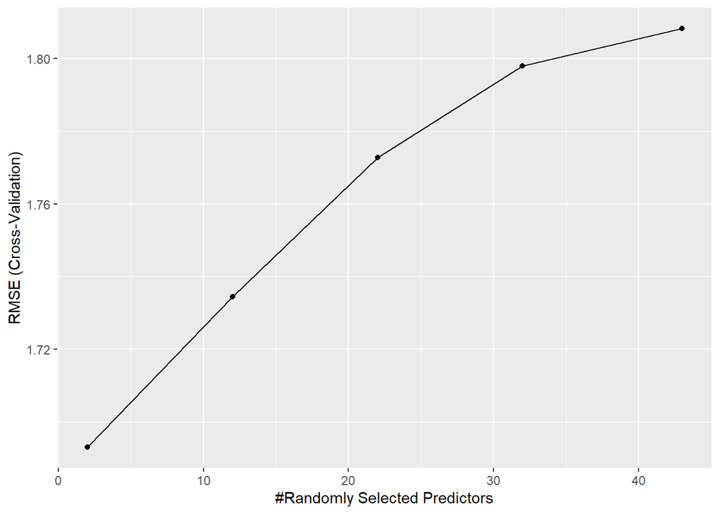

```r
ggplot(train.randomf)
```

```r
test.randomf  <- predict(train.randomf, newdata=test)
error.randomf <- test$Rating-test.randomf
```

#### Modelo KNN

```r
train.knn <- train(Rating ~ City + Gender + Weekday + Payment
                       +City*Gender*Weekday,
                   data=train, method="knn",
                   trControl = trainControl("cv", number=15),
                   preProcess = c("center","scale"),
                   tuneLength = 5
)

print(train.knn)
```

```
## k-Nearest Neighbors
##
## 700 samples
##   4 predictor
##
## Pre-processing: centered (43), scaled (43)
## Resampling: Cross-Validated (15 fold)
## Summary of sample sizes: 654, 653, 653, 652, 653, 654, ...
## Resampling results across tuning parameters:
##
##   k   RMSE      Rsquared    MAE
##    5  1.806845  0.01940343  1.505911
##    7  1.771926  0.02730566  1.489411
##    9  1.771295  0.01943599  1.488637
##   11  1.745766  0.01928835  1.475439
##   13  1.731602  0.02483634  1.461014
##
## RMSE was used to select the optimal model using the smallest value.
## The final value used for the model was k = 13.
```

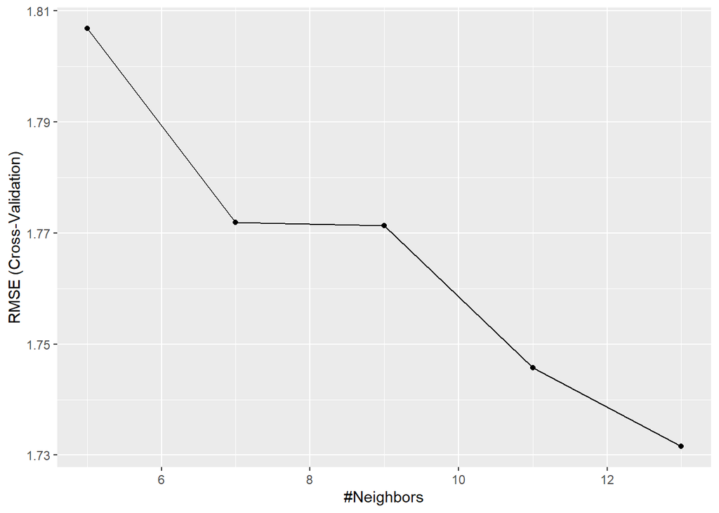

```r
ggplot(train.knn)
```

```r
test.knn  <- predict(train.knn, newdata=test)
error.knn <- test$Rating-test.knn
```

#### Regresión lineal

```r
### Ejecutar KNN

train.lm <- train(Rating ~ City + Gender + Weekday + Payment
                       +City*Gender*Weekday,
                   data=train, method="lm",
                   trControl = trainControl("cv", number=15),
                   preProcess = c("center","scale"),
                   tuneLength = 5
)

print(train.lm)
```

```
## Linear Regression
##
## 700 samples
##   4 predictor
##
## Pre-processing: centered (43), scaled (43)
## Resampling: Cross-Validated (15 fold)
## Summary of sample sizes: 653, 655, 653, 653, 653, 653, ...
## Resampling results:
##
##   RMSE      Rsquared   MAE
##   1.727845  0.0355758  1.463442
##
## Tuning parameter 'intercept' was held constant at a value of TRUE
```

```r
test.lm  <- predict(train.lm, newdata=test)
error.lm <- test$Rating-test.lm
```

Para comparar la capacidad de los modelos de machine learning frente a la regresión lineal debemos recordar que estos modelos son muy útiles cuando el foco del problema está en el pronóticos de relaciones complejas y no lineales, en cambio las regresiones lineales son muy útiles para entender la relación de las variables con los componentes de la regresión.

En base a ese razonamiento, para el enfoque teórico sería más útil realizar una regresión lineal que un modelo de Machine Learning, con el objetivo de entender como afectan las variables al Rating. Sin embargo al ser los de Machine Learning modelos mucho más complejos que pueden observar relaciones no lineales, estos suelen dar mejores resultados en capacidad predictiva.

Para comprobar esto se pueden comparar los errores de los modelos ML versus la regresión lineal, observandose los siguientes resultados:

```r
#RSME
ventas.test <- data.frame(  knn=test.knn,  rf=test.randomf,lm=test.lm, ventas=ytest)# agregar lm=test.lm,
error.test <- data.frame( knn=error.knn, rf=error.randomf,lm=error.lm)#agregar lm=error.lm,

summary(abs(error.test))
```

```
##       knn                rf                 lm
##  Min.   :0.03571   Min.   :0.007255   Min.   :0.01338
##  1st Qu.:0.79643   1st Qu.:0.860698   1st Qu.:0.82256
##  Median :1.61385   Median :1.603702   Median :1.68205
##  Mean   :1.60450   Mean   :1.578217   Mean   :1.62716
##  3rd Qu.:2.40417   3rd Qu.:2.238001   3rd Qu.:2.34379
##  Max.   :3.88571   Max.   :3.396589   Max.   :3.86451
```

```r
summary(error.test)
```

```
##       knn                rf                lm
##  Min.   :-3.4143   Min.   :-2.9838   Min.   :-3.6650
##  1st Qu.:-1.3418   1st Qu.:-1.3064   1st Qu.:-1.3893
##  Median : 0.3536   Median : 0.4016   Median : 0.3414
##  Mean   : 0.2466   Mean   : 0.2393   Mean   : 0.2170
##  3rd Qu.: 1.8893   3rd Qu.: 1.8293   3rd Qu.: 1.8435
##  Max.   : 3.8857   Max.   : 3.3966   Max.   : 3.8645
```

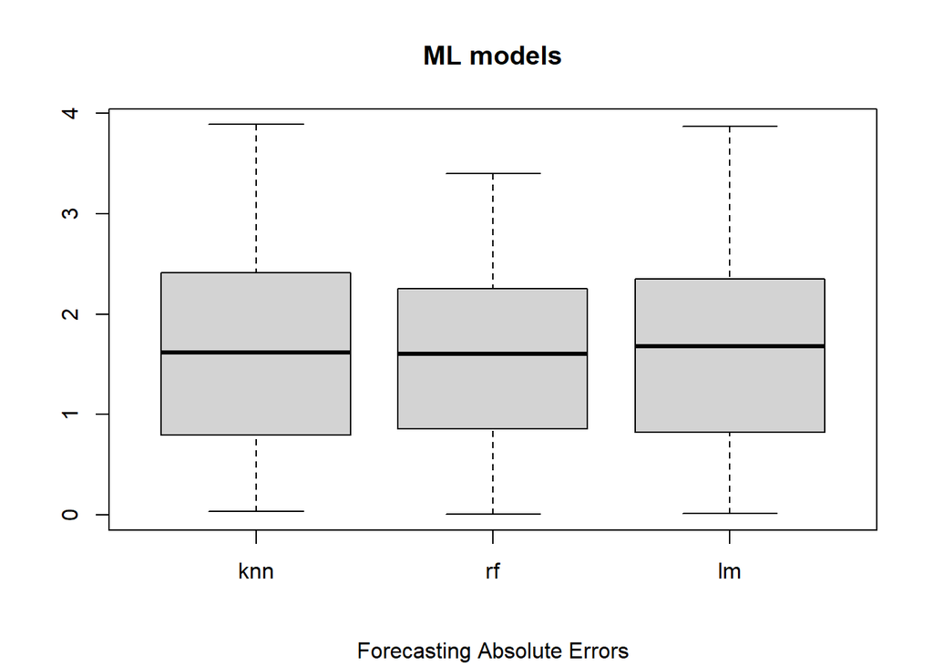

```r
boxplot(abs(subset(error.test))); title(main="ML models", sub="Forecasting Absolute Errors")
```

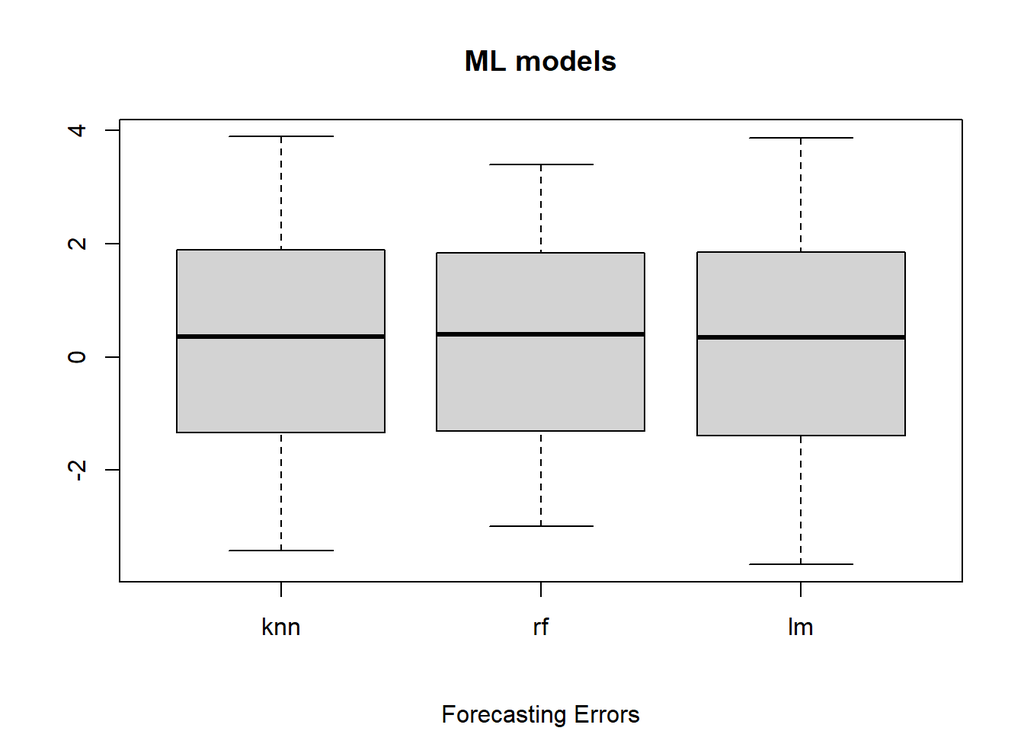

```r
boxplot(subset(error.test)); title(main="ML models", sub="Forecasting Errors")#, select=-lm
```

En general se ve que los errores son menores para los modelos de Machine Learning en particular para el de random forest, lo cual concuerda con la intuición de que estos tienen mejor capacidad predictiva para modelos más complejos, y servirían mejor para el objetivo de predecir el rating.

#### Pregunta 4

(0.5 puntos) Compare las fortalezas y debilidades de los modelos anteriores, evalúe de acuerdo a algunas de las métricas que vimos en clases y discuta qué modelo recomendaría usar.

Además se debe considerar la forma en que trabajan los modelos. El modelo KNN se basa en encontrar grupos de objetos similares, y luego usa el valor de respuesta media de k observaciones como el resultado previsto, en este caso dando k=13. El modelo de Random Forest es un conjunto de varios árboles de decisión que van agregando grupos para predecir cual será el objetivo, esta agrupación hace que este tenga menos variabilidad al clasificar, y suele entregar mejores predicciones. Y el modelo de regresión lineal busca minimizar la distancia entre la regresión y los datos buscando un mejor ajuste, sin embargo no es capaz de encontrar relaciones más complejas. En esto se observa que el modelo más adecuado vuelve a ser el Random Forest, pues se ha verificado la importancia de la interacción entre variables para comprender el rating.

Finalmente se puede confirmar que el mejor modelo para determinar el rating es el de Random Forest, pues cumple con minimizar el error y va clasificando según distintos parámetros hasta encontrar el rating esperado de cierto cliente, lo cual coincide con lo que hemos planteado en los modelos anteriores.

#### Pregunta 5

(2.0 puntos) En esta parte, se compararán los grados de satisfacción entre las distintas salas de la cadena de supermercados. Para lo siguiente usted deberá clasificar cada evaluación de la calidad de servicios de acuerdo a si el cliente está o no satisfecho. Para eso puede considerar que un cliente está satisfecho si tiene un Rating mayor o igual a los 7 puntos. Con esto:

**a)**Estimar un modelo de decisión homogéneo para cada sucursal y compare sus resultados entre sucursales. Discuta brevemente sus resultados.

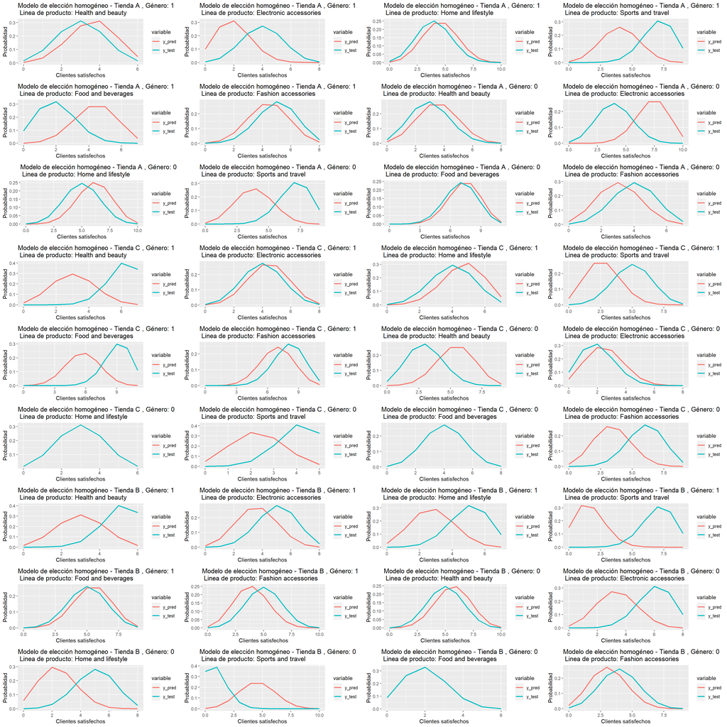

```r
ventas <- ventas %>%
  mutate(Satisfecho = ifelse(Rating >= 7,1,0), Compras = 1)

genero <- unique(ventas$Gender)
producto <- unique(ventas$Product.line)
branch <- unique(ventas$Branch)

g <- list()

i <- 0
for (tienda in branch){
  for (m_h in genero){
    for (pr in producto){
      #print(paste(tienda, m_h, dia))

      i <- i + 1
      data <- ventas %>%
        filter(Branch == tienda) %>%
        filter(Gender == m_h) %>%
        filter(Product.line == pr)

      train <- data %>% sample_frac(0.7)

      test <- anti_join(data, train, by="Invoice.ID")

      train_prob <- train %>%
        summarise(TR=sum(Satisfecho)/sum(Compras),
                    Y=sum(Satisfecho),
                    m=sum(Compras))

      test_prob <- test %>%
        summarise(TR=sum(Satisfecho)/sum(Compras),
                    Y=sum(Satisfecho),
                    m=sum(Compras))

      x_test <- seq(0,test_prob$m,by = 1)

      y_pred <- dbinom(x_test, test_prob$m, train_prob$TR)

      y_test <- dbinom(x_test, test_prob$m, test_prob$TR)

      x_norm <- x_test

      df_binomial <- data.frame(y_pred, y_test, x_norm)

      d <- melt(df_binomial, id.vars="x_norm")
      d <- drop_na(d)

      plot <- ggplot(d, aes(x_norm,value, col=variable))+
        geom_line(size=1)+
        labs(x='Clientes satisfechos',y='Probabilidad',
               title=paste('Modelo de elección homogéneo - Tienda', tienda,
                           ', Género:', m_h, '\n Linea de producto:', pr))
      g[[i]] <- plot
    }
  }
}

grid.arrange(grobs = g, ncol = 4)
```

**b)**Estimar un modelo de decisión heterogéneo para cada sucursal y compare sus resultados entre sucursales. Discuta brevemente sus resultados.

```r
#Modelo Heterogéno con variables explicativas

n = length(genero) * length(branch) * length(producto)

data_segmentos <- data.frame(matrix(ncol = 4, nrow = 0))
x <- c("ms", "xs", "Tipo", "Nombre")
colnames(data_segmentos) <- x

for (tienda in branch){
  for (m_h in genero){
    for (pr in producto){

      data <- ventas %>%
        filter(Branch == tienda) %>%
        filter(Gender == m_h) %>%
        filter(Product.line == pr)

      train <- data %>% sample_frac(0.7)

      test <- anti_join(data, train, by="Invoice.ID")

      train_prob <- train %>%
        summarise(xs=sum(Satisfecho),
                    ms=sum(Compras)) %>%
        mutate(Tipo = 'Train',
               Nombre = paste(tienda, m_h, pr, sep = "--"))

      test_prob <- test %>%
        summarise(xs=sum(Satisfecho),
                    ms=sum(Compras)) %>%
        mutate(Tipo = 'Test',
               Nombre = paste(tienda, m_h, pr, sep = "--"))

      data <- rbind(train_prob, test_prob)
      data_segmentos <- rbind(data_segmentos, data)
    }
  }
}

data_segmentos$id <- as.numeric(as.factor(data_segmentos$Nombre))

data_train <- data_segmentos %>%
  filter(Tipo == 'Train') %>%
  arrange(id)

data_test <- data_segmentos %>%
  filter(Tipo == 'Test') %>%
  arrange(id)
```

```r
ll.bb <-function(theta){
  myalpha = exp(theta[1])
  mybeta  = exp(theta[2])
  pr = array(NA, dim=nrow(data_train))
  for(i in 1:nrow(data_train)){
    pr[i] = with(data_train, choose(ms[i],xs[i])*beta(myalpha+xs[i],mybeta+ms[i]-xs[i]) / beta(myalpha,mybeta))
  }
  return(-sum(log(pr)))
}


theta.start = rep(6,3)
cat("Maximizing likelihood beta binomial ... \n")
```

```
## Maximizing likelihood beta binomial ...
```

```r
mle.bb = optim(par=theta.start, fn=ll.bb, hessian=TRUE, method="BFGS", control = list(maxit=30000, trace=TRUE, REPORT=10))
myalpha = exp(mle.bb$par[1])
mybeta  = exp(mle.bb$par[2])
print(c(myalpha, mybeta))
```

```
## [1] 16.03340 15.91294
```

```r
ep = array(NA, dim=nrow(data_test))
for(i in 1:nrow(data_test)){
  ep[i] = with(data_test, (myalpha+xs[i])/(myalpha+mybeta+ms[i]))
}
data_test$Ep <- ep
```

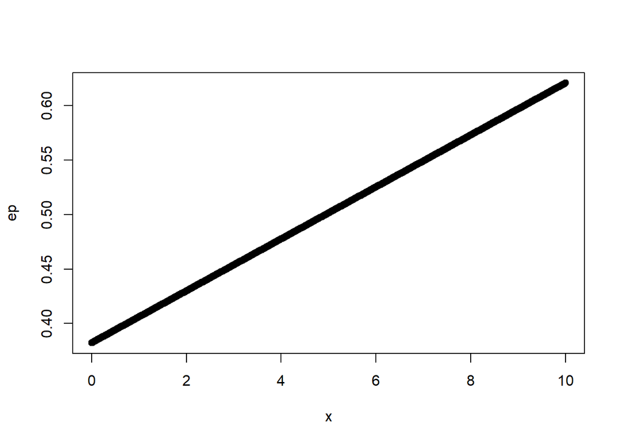

```r
m=10
x <- seq(from = 0, to = m, by = 0.01)
beta <- dbeta(x, myalpha, mybeta)

ep <- (myalpha+x)/(myalpha+mybeta+m)
plot(x, ep)
```

## Resumen y Conclusiones

Documenta acá el resumen y las conclusiones principales (esto te servirá para la presentación del jueves 6)

```r
#Resumen y conclusiones
```

[output not shown]

## Anexos

Documenta acá cualquier otro adicional que consideres útil tener de referencia.